# Predictive Assignment rightup

## Acknowledgements:

#### The data set used here is from the Weight Lifting Exercise Dataset. The original research that produced this data set is published at: Velloso, E.; Bulling, A.; Gellersen, H.; Ugulino, W.; Fuks, H. Qualitative Activity Recognition of Weight Lifting Exercises. Proceedings of 4th International Conference in Cooperation with SIGCHI (Augmented Human ’13). Stuttgart, Germany: ACM SIGCHI, 2013.

## BackGround:

#### Using devices such as Jawbone Up, Nike FuelBand, and Fitbit it is now possible to collect a large amount of data about personal activity relatively inexpensively. These type of devices are part of the quantified self movement - a group of enthusiasts who take measurements about themselves regularly to improve their health, to find patterns in their behavior, or because they are tech geeks. One thing that people regularly do is quantify how much of a particular activity they do, but they rarely quantify how well they do it. In this project, your goal will be to use data from accelerometers on the belt, forearm, arm, and dumbell of 6 participants. They were asked to perform barbell lifts correctly and incorrectly in 5 different ways. More information is available from the website here: http://groupware.les.inf.puc-rio.br/har (see the section on the Weight Lifting Exercise Dataset).

#### Read in the data for training and testing data sets

```r
training_data <- read.csv('D:\\downloads\\Class\\Practical Machine Learning\\pml-training.csv', row.names = 1, stringsAsFactors = FALSE,
           na.strings = c("NA", "", "#DIV/0!"))
testing_data <- read.csv('D:\\downloads\\Class\\Practical Machine Learning\\pml-testing.csv', row.names = 1, stringsAsFactors = FALSE,
           na.strings = c("NA", "", "#DIV/0!"))
```

#### Looking at the data there are allot of na records will have to filter out

```r
## get the good data columns that apply can be focused on
gooddatacolumns <- colnames(training_data[colSums(is.na(training_data)) == 0])[-(1:7)]
gooddatatrain <- training_data[gooddatacolumns]
gooddatatrain$classe <- factor(gooddatatrain$classe)

gooddatacolumnst <- colnames(testing_data[colSums(is.na(testing_data)) == 0])[-(1:7)]
gooddatatest <- testing_data[gooddatacolumnst]
```

## create a traing and testing exampes

```r
inTrain=createDataPartition(y=gooddatatrain$classe, p=0.6, list=FALSE)
    trainingdata <-gooddatatrain[inTrain,]
    testingdata <- gooddatatrain[-inTrain,]
```

## use rpart

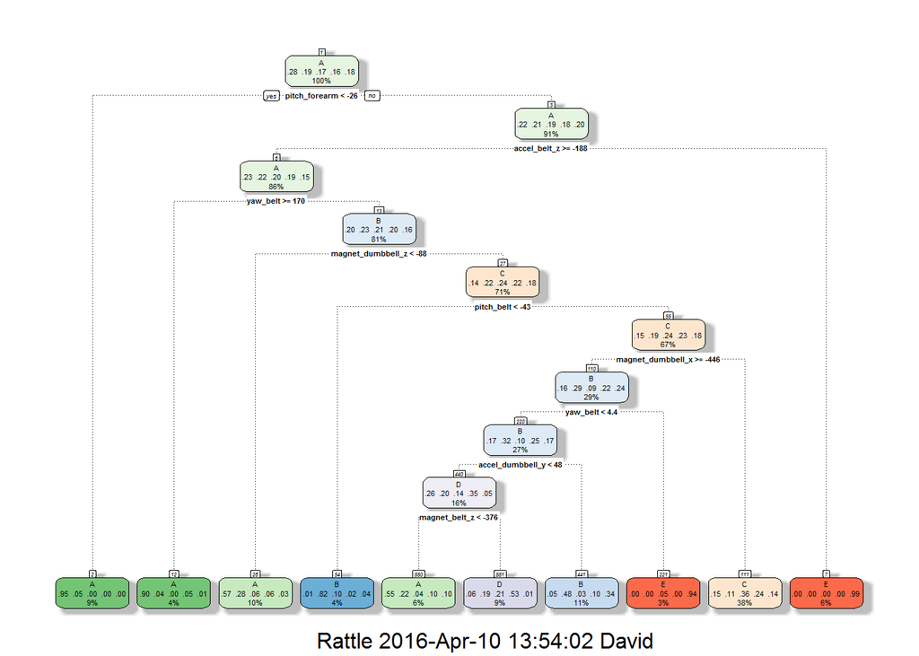

```r
 modfit1 <- train(classe ~ .,method='rpart',data=trainingdata)
    fancyRpartPlot(modfit1$finalModel)
```

```r
    pred=predict(modfit1,newdata=testingdata)
    z=confusionMatrix(pred,testingdata$classe)
    z$table
```

```
##           Reference
## Prediction    A    B    C    D    E
##          A 1684  378   40  147   70
##          B   59  711   51   94  305
##          C  441  297 1102  648  488
##          D   45  132  161  397    5
##          E    3    0   14    0  574
```

```r
    z$overall[1]
```

```
##  Accuracy
## 0.5694621
```

## Random forest method to do the prediction

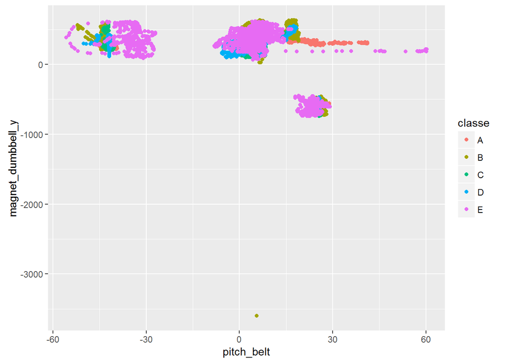

```r
modfit2=randomForest(classe~., data=trainingdata, method='class')
    pred2 = predict(modfit2,testingdata,type='class')
    qplot(pitch_belt, magnet_dumbbell_y, colour=classe, data=trainingdata)
```

```r
    z2=confusionMatrix(pred2,testingdata$classe)
    z2$table
```

```
##           Reference
## Prediction    A    B    C    D    E
##          A 2231    9    0    0    0
##          B    0 1508    3    0    0
##          C    0    1 1363   12    2
##          D    0    0    2 1273    3
##          E    1    0    0    1 1437
```

```r
   z2$overall[1]
```

```
##  Accuracy
## 0.9956666
```

## If 99% we will accept this predictive model

## we will use the random forest method to go against the testing data

```r
pred3 =  predict(modfit2,gooddatatest,type='class')
pred3
```

```
##  1  2  3  4  5  6  7  8  9 10 11 12 13 14 15 16 17 18 19 20
##  B  A  B  A  A  E  D  B  A  A  B  C  B  A  E  E  A  B  B  B
## Levels: A B C D E
```